# 3 Funciones elementales

## 3.1 Ejercicios Resueltos

Para la realización de esta práctica se requieren los siguientes paquetes:

```julia
using Plots  # Para el dibujo de gráficas.
#plotlyjs()  # Para obtener gráficos interactivos.
using SymPy # Para el cálculo simbólico.
using MTH229 # Para restringir la gráfica de una función a su dominio.
using LaTeXStrings  # Para usar código LaTeX en los gráficos.
using Latexify  # Para convertir expresiones a código LaTeX.
```

**Ejercicio 3.1** La siguiente tabla contiene el número de bacterias en un cultivo cada hora que pasa.

| Horas | Bacterias |
| --- | --- |
| 0 | 1 |
| 1 | 2 |
| 2 | 4 |
| 3 | 8 |
| 4 | 16 |
| 5 | 32 |
| 6 | 64 |
| 7 | 128 |

Dibujar una gráfica con la evolución del la población de bacterias.

**Ayuda**

Definir los valores de las horas en un vector `x` y el número de bacterias en otro `y` y luego utilizar la función [`scatter(x,y)`](https://aprendeconalf.es/manual-julia/graficos.html#a%C3%B1adir-puntos-a-una-gr%C3%A1fica) del paquete `Plots` para dibujar una gráfica de puntos.

**Solución**

```julia
using Plots
horas = 0:7
bacterias = [1, 2, 4, 8, 16, 32, 64, 128]
scatter(horas, bacterias, xlab="Horas", ylab="Bacterias", title="Evolución de la población de bacterias", legend=false)
```

[figure not shown]

¿Los pares dados en la tabla forman una función?

**Solución**

Si, porque para cada hora hay a lo sumo un número de bacterias con el que se relaciona.

¿Qué fórmula crees que explica la evolución del número de bacterias en función de las horas que pasan? Dibuja en la gráfica anterior la función con esa fórmula.

**Ayuda**

Para añadir una nueva gráfica a una anterior se añade un signo de exclamación `!` a la función de graficación. Para una gráfica de líneas, utilizar la función [`plot!`](https://aprendeconalf.es/manual-julia/graficos.html#gr%C3%A1fica-de-una-funci%C3%B3n-de-una-variable) del paquete `Plots`, pasándole el nombre de la función si se ha definido previamente o la [definición anónima de la función](https://aprendeconalf.es/manual-julia/funciones.html#funciones-an%C3%B3nimas)

**Solución**

```julia
using Plots
plot!(x -> 2^x)
```

[figure not shown]

**Ejercicio 3.2** En el lanzamiento vertical de un objeto, la posición que ocupa el objeto en cada instante $t$, viene dado por la función

$$y(t) = y_0+v_0t+\frac{1}{2}gt^2$$

donde $y_0$ es la altura inicial del objeto, $v_0$ la velocidad inicial con que se lanza, y $g$ es la aceleración de la gravedad. Una pelota se lanza verticalmente desde la ventada de un edificio a 5 m de altura, con una velocidad inicial de $10$ m/s. Dibujar la gráfica de la posición de la pelota en función del tiempo, tomando una aceleración de la gravedad $g=-9.8$ m/s².

**Ayuda**

Declarar $t$ como una variable simbólica usando el paquete [`SymPy`](https://docs.juliahub.com/SymPy/KzewI/1.0.29/introduction/#Symbols-1), definir después las constantes $y_0$, $v_0$ y $g$, y luego definir la función $y(t)$ mediante la fórmula dada.

Para dibujar la gráfica de la función, usar la función `plot` pasándole el nombre de la función. Como no tienen sentido los instantes negativos, ni las posiciones negativas, restringir la ventana de graficación a valores de $t$ y de $y$ positivos usando los parámetros [`xlim`](https://aprendeconalf.es/manual-julia/graficos.html#ventana-de-graficaci%C3%B3n) e [`ylim`](https://aprendeconalf.es/manual-julia/graficos.html#ventana-de-graficaci%C3%B3n).

**Solución**

```julia
using Plots, SymPy
@syms t  #Declaramos t como una variable simbólica
y₀ = 5
v₀ = 10
const gravedad = -9.8  #Declaramos la gravedad como una constante
y0(t) = y₀+v₀*t+ 1/2*gravedad*t^2
plot(y0, xlims=(0,3), ylims=(0,15), label="Pelota", xlab="Tiempo (s)", ylab="Altura (m)")
```

[figure not shown]

**Ayuda**

La función que define la posición del ascensor que baja desde una altura $y_1$ con una velocidad constante $v_1$ en cada instante $t$ es $y(t) = y_1-v_1t$.

**Solución**

```julia
y₁ = 8
v₁ = 2
y1(t) = y₁-v₁*t
plot!(y1, label="Ascensor")
```

[figure not shown]

¿En qué instantes el ascensor estará a la misma altura de la pelota? Dibujar los puntos correspondientes a esos instantes en la gráfica anterior.

**Solución**

```julia
sol = solve(y0(t)-y1(t))
print("Instantes: ", sol)
scatter!(sol, y1.(sol), label="Intersección")
```

```
Instantes: Sym[0.282613815574341, 2.16636577626239]
```

[figure not shown]

**Ejercicio 3.3** El volumen de un globo esférico depende del radio según la función $v(r)= \frac{4}{3}\pi r^3$. Calcular la función que expresa el radio en función del volumen y dibujar su gráfica.

**Ayuda**

Declarar las variables simbólicas `r` y `v` usando el paquete `SymPy` y definir la función `vol(r)` que expresa el volumen del globo en función del radio.

Después utilizar la función [`solve`](https://docs.juliahub.com/SymPy/KzewI/1.0.29/introduction/#The-solve-function-1) del paquete `SymPy` para despejar `r` de la ecuación `v-vol(r)=0`.

**Solución**

```julia
using Plots, SymPy
@syms r v
vol(r) = 4/3*pi*r^3
rad = solve(v-vol(r),r)[1]
plot(rad, xlab="Volumen (m³)", ylab="Radio (m)", legend=false)
```

[figure not shown]

Si empezamos a introducir helio en el globo de manera que su volumen a los $t$ minutos viene dado por la función $v(t)=t^2+2t$, dibujar la gráfica de la función que da el radio en cada instante.

**Ayuda**

Declarar las variables simbólicas `t` usando el paquete `SymPy` y definir la función `vol(t)` que expresa el volumen del globo en función del tiempo.

Después utilizar a el operador de composición $\circ$ para componer la función del volumen con la función del radio.

**Solución**

```julia
@syms t
vol(t)=t^2+2t
plot(rad∘vol, xlim=(0,10), xlab="Tiempo (min)", ylab="Radio (m)")
```

[figure not shown]

Si el globo explota cuando el radio alcanza los 3 m, ¿cuándo explotará el globo?

**Solución**

```julia
sol = solve((rad∘vol)(t)-3)
```

```
2-element Vector{Sym}:
 -11.6816354332674
  9.68163543326738
```

El globo explotará a los 9.68163543326738 minutos.

**Ejercicio 3.4** Dibujar la gráfica de la función

$$f(x) = 2x^3-3x^2-12x+4$$

en el intervalo $[-3,4]$ y determinar, observando la gráfica, lo siguiente:

**Ayuda**

Definir la función y usar la función [`plot`](https://docs.juliaplots.org/latest/tutorial/#Basic-Plotting:-Line-Plots) del paquete `Plots`.

**Solución**

```julia
using Plots, LaTeXStrings
f(x) = 2x^3-3x^2-12x+4
plot(f, -3, 4, label=L"$f(x) = 2x^3-3x^2-12x+4$")
```

[figure not shown]

1. Dominio

**Solución**

$Dom(f)=\mathbb{R}$

2. Imagen

**Solución**

$Im(f)=\mathbb{R}$

3. Raíces

**Solución**

```julia
using SymPy
@syms x
f(x) = 2x^3-3x^2-12x+4
raices = solve(f(x))  # Solución exacta
print(raices)
N(raices)  # Solución aproximada con decimales
```

```
Sym[-2, 7/4 - sqrt(33)/4, sqrt(33)/4 + 7/4]
```

```
3-element Vector{Real}:
 -2
  0.313859338365492835037347132945267670444933885504301908075030632358524819635648
  3.186140661634507164962652867054732329555066114495698091924969367641475180364343
```

Hay tres raíces en $x=-2$, $x=0.31$ y $x=3.19$ aproximadamente.

4. Signo

**Solución**

Intervalos con $f(x)$ negativa: $(-\infty, -2)\cup (0.31,3.19)$.  
Intervalos con $f(x)$ positiva: $(-2,0.31)\cup (3.19,\infty)$.

5. Crecimiento

**Solución**

Intervalos con $f(x)$ creciente: $(-\infty, -1)\cup (2,\infty)$.  
Intervalos con $f(x)$ decreciente: $(-1,2)$.

6. Extremos

**Solución**

Máximo relativo en $x=-1$ y el valor máximo es $f(-1)=11$.  
Mínimo relativo en $x=2$ y el valor del mínimo es $f(2)=-16$.

7. Concavidad

**Solución**

Intervalos de concavidad hacia arriba: $(0.5,\infty)$.  
Intervalos de concavidad hacia abajo: $(-\infty, 0.5)$.

8. Puntos de inflexión

**Solución**

Punto de inflexión en $x=0.5$.

**Ejercicio 3.5** Dibujar la gráfica de la función

$$g(t) = \frac{t^4+19t^2-5}{t^4+9t^2-10}$$

en el intervalo $[-8,8]$ y determinar, observando la gráfica, lo siguiente:

**Ayuda**

Usar la función `plot` como en el ejercicio anterior con el parámetro `aspect_ratio=1.0` para que los ejes tengan la misma escala.

Para respetar las discontinuidades autilizar la función `rangeclamp()` del paquete `MTH229`.

**Solución**

```julia
g(t) = (t^4+19t^2-5) / (t^4+9t^2-10)
plot(rangeclamp(g), -8, 8, aspect_ratio=1.0, ylims=(-5,5) , xticks =Vector(-10:10), yticks = Vector(-5:5), label=L"$g(t) = \frac{t^4+19t^2-5}{t^4+9t^2-10}$")
```

[figure not shown]

1. Dominio. ¿Qué pasa si aplicamos la función a algún valor fuera de su dominio?

**Solución**

$Dom(f)=\mathbb{R}\setminus\{-1,1\}$

```julia
g(-1), g(1)
```

```
(Inf, Inf)
```

Como se observa, al aplicar la función a $-1$ y $1$ se obtiene $\infty$.

2. Imagen

**Solución**

$Im(f)=\mathbb{R}\setminus (0.5,1]$

3. Asíntotas. Dibujarlas.

**Ayuda**

Buscar las asíntotas verticales en los puntos fuera del dominio de la función.

Para dibujar asíntotas verticales usar la función [`vline`](https://docs.juliaplots.org/latest/api/#Plots.vline-Tuple) del paquete `Plots`, y para dibujar las asíntotas horizontales usar la función [`hline`](https://docs.juliaplots.org/latest/api/#Plots.hline-Tuple).

**Solución**

```julia
vline!([-1,1], label="Asíntotas verticales")
hline!([1], label="Asíntotas horizontales", legend=:bottomright)
```

[figure not shown]

Asíntotas verticales en $x=-1$ y $x=1$.  
Asíntotas horizontales en $y=1$.  
No hay asíntotas oblicuas.

4. Raíces

**Solución**

Hay dos raíces en $x=-0.5$ y $x=0.5$ aproximadamente.

5. Signo

**Solución**

Intervalos con $f(x)$ positiva: $(-\infty,-1)\cup (-0.5,0.5)\cup (1,\infty)$.  
Intervalos con $f(x)$ negativa: $(-1,-0.5)\cup (0.5,1)$.

5. Crecimiento

**Solución**

Intervalos con $f(x)$ creciente: $(-\infty, -1)\cup (-1,0)$.  
Intervalos con $f(x)$ decreciente: $(0,1)\cup (1,\infty)$.

6. Extremos

**Solución**

Máximo relativo en $x=0$ y el valor máximo es $g(0)=0.5$.  
No hay mínimos relativos.

7. Concavidad

**Solución**

Intervalos de concavidad hacia arriba: $(-\infty,-1)\cup (1,\infty)$.  
Intervalos de concavidad hacia abajo: $(-1,1)$.

8. Puntos de inflexión

**Solución**

No hay puntos de inflexión.

**Ejercicio 3.6** Dibujar la gráficas de las siguientes funciones exponenciales $2^x$, $e^x$, $0.5^x$, $0.7^x$ y responder a las siguientes preguntas comparando las gráficas.

**Solución**

```julia
using Plots, LaTeXStrings
plot(2^x, -2, 2, label=L"$2^x$")
plot!(exp(x), label=L"$e^x$")
plot!(0.5^x, label=L"$2^x$")
plot!(0.7^x, label=L"$2^x$")
```

[figure not shown]

1. ¿Cuál es el dominio de una función exponencial?

**Solución**

$\mathbb{R}$.

2. ¿Cuál es la imagen de una función exponencial?

**Solución**

$\mathbb{R}^+$.

3. ¿Cómo es el crecimiento de una función exponencial?

**Solución**

$a^x$ es creciente si $a>1$ y decreciente si $0<a<1$.

4. ¿Tienen extremos una función exponencial?

**Solución**

No

5. ¿Cómo es la curvatura de una función exponencial?

**Solución**

Es cóncava hacia arriba.

**Ejercicio 3.7** Dibujar la gráficas de las funciones trigonométricas $\operatorname{sen}(x)$, $\operatorname{sen}(x+2)$, $\operatorname{sen}(x)+2$, $\operatorname{sen}(2x)$ y $2\operatorname{sen}(x)$, y completar la siguiente tabla estudiando su periodo y amplitud.

| Función | Periodo | Amplitud |
| --- | --- | --- |
| $\operatorname{sen}(x)$ |  |  |
| $\operatorname{sen}(x+2)$ |  |  |
| $\operatorname{sen}(x)+2$ |  |  |
| $\operatorname{sen}(2x)$ |  |  |
| $2\operatorname{sen}(x)$ |  |  |

¿Qué conclusiones sacas?

**Ayuda**

El periodo es el mínimo intervalo en el que la gráfica de la función se repite, y la amplitud es la mitad de la diferencia entre el máximo y el mínimo de la función.

**Solución**

```julia
using Plots, LaTeXStrings
plot(sin(x), -2*pi, 2*pi, label=L"$\operatorname{sen}(x)$")
plot!(sin(x+2), label=L"$\operatorname{sen}(x+2)$")
plot!(sin(x)+2, label=L"$\operatorname{sen}(x)+2$")
plot!(sin(2x), label=L"$\operatorname{sen}(2x)$")
plot!(2sin(x), label=L"$2\operatorname{sen}(x)$")
```

[figure not shown]

| Función | Periodo | Amplitud |
| --- | --- | --- |
| $\operatorname{sen}(x)$ | $2\pi$ | 1 |
| $\operatorname{sen}(x+2)$ | $2\pi$ | 1 |
| $\operatorname{sen}(x)+2$ | $2\pi$ | 1 |
| $\operatorname{sen}(2x)$ | $\pi$ | 1 |
| $2\operatorname{sen}(x)$ | $2\pi$ | 2 |

Se observa que al sumar una constante a la función seno o a su argumento, el periodo y la amplitud no cambian. Sin embargo, si se multiplica por una constante el seno, cambia la amplitud, y si se multiplica su argumento, cambia el periodo.

**Ejercicio 3.8** Dibujar la gráfica de la función a trozos

$$h(x)=
\begin{cases}
-2x & \mbox{si } x\leq 0;\\
x^2 & \mbox{si } 0< x \leq 2;\\
4 & \mbox{si } 2< x
\end{cases}$$

**Ayuda**

Usar el [operador condicional](https://aprendeconalf.es/manual-julia/estructuras-control.html#operador-condicional) anidado.

**Solución**

```julia
using Plots
h(x) = x<=0 ? -2x : x<=2 ? x^2 : 4
plot(h, legend = false)
```

[figure not shown]

**Ejercicio 3.9** Una hormiga se mueve sobre el plano real de manera que en cada instante $t$ su posición viene dada por las funciones

$$\begin{cases}
x=\operatorname{sen}(t) \\
y=\operatorname{sen}(2t)
\end{cases}$$

Dibujar la gráfica de la trayectoria de la hormiga.

**Solución**

```julia
using Plots
u1(t)=sin(t)
v1(t)=sin(2t)
plot(u1, v1, 0, 4pi, aspect_ratio=1.0, legend = false)
```

[figure not shown]

## 3.2 Ejercicios propuestos

**Ejercicio 3.10** ¿Cuáles de las siguientes funciones tienen dominio $\mathbb{R}$ e imagen $\mathbb{R}^+\cup\{0\}$?

\(x^4-2x^3+4x\)

\(1/x^2\)

\(\sqrt(x)\)

\(|x|\)

\(2^x\)

**Ejercicio 3.11** Dibujar las gráficas de las funciones logarítmicas $\ln(x)$, $\log_2(x)$ y $\log_{0.5}(x)$ y contestar a las siguientes preguntas.

1. ¿Cuál es el dominio de una función logarítmica?

\(\mathbb{R}^+\)

\(\mathbb{R}^+\cup \{0\}\)

\(\mathbb{R}\)

\(\mathbb{R}\setminus\{0\}\)

Las otras opciones son falsas.

2. ¿Cuál es la imagen de una función logarítmica?

Las otras opciones son falsas.

\(\mathbb{R}\setminus\{0\}\)

\(\mathbb{R}^-\)

\(\mathbb{R}^+\)

\(\mathbb{R}\)

3. ¿Cómo es el crecimiento la función logarítmica $\log_a(x)$?

Creciente si \(0 < a < 1\)

Decreciente si \(0 < a <1\)

Creciente si \(a<1\)

Creciente si \(a>1\)

4. ¿Cómo es la concavidad la función logarítmica $\log_a(x)$?

Cóncava hacia abajo si \(a<1\)

Cóncava hacia arriba si \(a>1\)

Cóncava hacia abajo si \(0 < a < 1\)

Cóncava hacia arriba si \(0 < a < 1\)

**Ejercicio 3.12** ¿Cuál es el periodo y la amplitud de la función $2\cos(x/2)$?

π y 2

2π y 1

2π y 2

4π y 2

4π y 1

**Ejercicio 3.13** ¿Cuál de las gráficas corresponde a la siguiente función paramétrica?

$$f(t)=
\begin{cases}
\operatorname{sen}(2t)-\cos(t) \\
\operatorname{sen}(t)+\cos(t)
\end{cases}$$

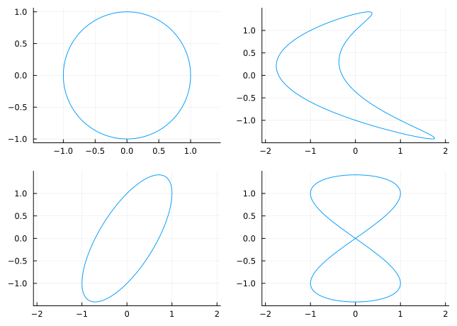